Skip to main content

# Rotational Symmetry

Rotation Groups — Simple Visual Examples

Change

Canonical Movements

Immunity

Groups

Published

July 26, 2026

Modified

November 28, 2026

## Introduction

Assume we have a plane 2D geomtric shape on the table. How would we rotate it with our hand? Two fingers: the thumb to **anchor** the rotation, and one other finger to rotate the object.

Where would you place your thumb? On the point where you imagine the **axis of rotation** to be; an imaginary line rising *vertically* from the surface. And the other finger would be placed *on the periphery* of the object. This is your repeatable **canonical movement** in this instance.

How do we describe this with math? Two ways. A `set`, and a `matrix`.

### Cyclic Symmetry Group

A **`cyclic symmetry group`** is a `set` $\mathbb{C}_{𝑛}$ contains the symmetries produced by repeatedly applying one basic rotation. For a 2D object, it has $n$ elements: the identity plus $n−1$ rotations by multiples of $360^\circ /n$. So what does this `set` contain?

$$\mathbb{C}_{𝑛} = \{ {e,r,r^2,…,r^{n−1}} \}
\tag{1}$$

where:

- $e$ is the identity operator: “do nothing.”
- $r$ is one basic rotation, usually by $360^\circ /n$
- $r^k$ means applying that rotation $k$ times, equivalent to rotating by $k \times 360^\circ /n$
- $r^n = e$ because $n$ repetitions return the object to its starting position.

[interactive chart not shown]

Figure 1: 5-fold Rotational Symmetry

**To recreate it:** Click on the “</>” symbol at the top of the embedded sketch, stop the execution, and copy the code. Open the [p5.js Web Editor](https://editor.p5js.org), replace the contents of `sketch.js` with the code, then click **Play**.

### Rotation as a Matrix Mutiplication

If we had a set of 2D points ${(x,y)}$ then we can write their rotation as a transformation of their coordinates to a new position, representing a rotation **about a notional axis of rotation**. What might such an axis look like?

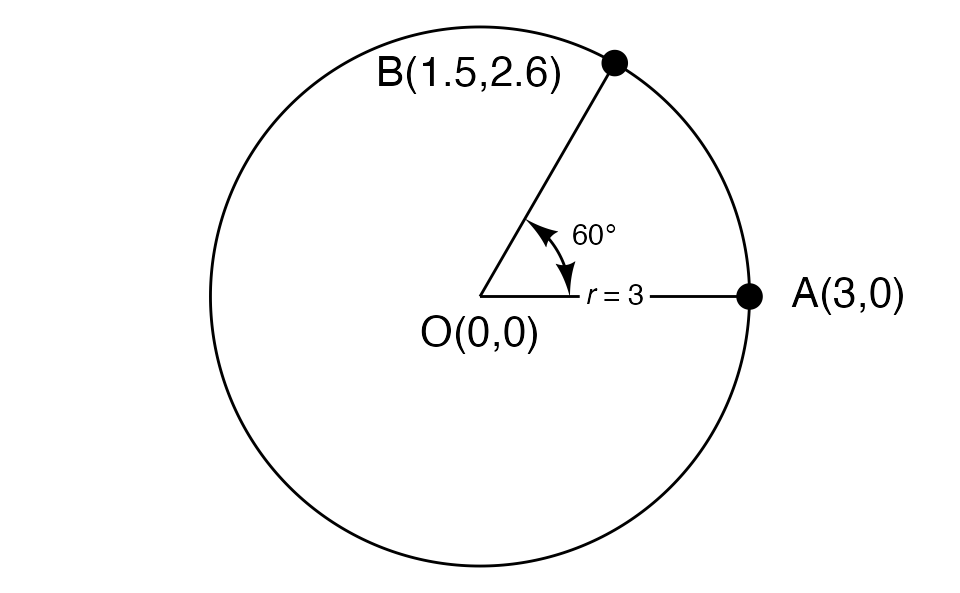

Figure 2: Rotation Matrix calculations

We rotate point $A$ about the origin $O$ and obtain $B$. And we transform the original coordinates of A to those of B, using a matrix multiplication:

$$\begin{pmatrix}
x_B \\
y_B
\end{pmatrix}
=
\begin{pmatrix}
\cos 60^\circ & -\sin 60^\circ \\
\sin 60^\circ & \cos 60^\circ
\end{pmatrix}
\begin{pmatrix}
x_A \\
y_A
\end{pmatrix}
\tag{2}$$

so:

$$x_B = x_A \cos 60^\circ - y_A \sin 60^\circ, \qquad
y_B = x_A \sin 60^\circ + y_A \cos 60^\circ$$

### Rotation in `p5.js`

In the `p5.js` sketch above, we have used functions such as:

```
push();
rotate(angle + (i * TWO_PI) / n);
fill(100, 150, 220, 180);
noStroke();
ellipse(80, 0, 30, 30);
pop();
```

This allows us to draw a circle at a given angle, return to the origin, rotate the entire canvas by a given angle, and draw another one and so on. The angle of rotation progressively increases, as desired.

The *return to origin* is accomplished by the `push()`/`pop()` combo-functions. Every time we call `push()`, we save the current transformation state, and every time we call `pop()`, we restore the previous transformation state, which is our `origin`, at ${(200,200)}$. This is useful for creating complex shapes and patterns that require multiple transformations.

The combination sequence of `push()`, `rotate()` and `pop()` helps us to create shapes that have rotational symmetry.

## Wait, But Why?

- Rotational Symmetry is one of the most-easily identified, and aesthetically pleasing symmetries
- Being able to use the `push()`, `rotate()` and `pop()` functions in `p5.js` helps us to simply and iteratively create complex rotationally-symmetric designs.

## References

1. [p5.js Reference `rotate`](https://p5js.org/reference/p5/rotate/)

Back to top